# 주제

자신의 팀에서 생각한 구체적인 주제를 작성하시오.

코로나19로 인해 경제적으로 피해를 입은 상인들이 어떻게 하면 매출액을 높여 매출을 복구시킬 수 있을지에 대해서 알아보자

## 1. 데이터 수집

데이터를 수집방법을 언급하고, 이를 데이터를 불러오는 과정을 제시하시오.

## 2. 데이터 분석

"데이터 수집"에서 가져온 데이터를 분석하고, 이 과정을 제시하시오.

## 3. 시각화

주제에 알맞은 방법으로 시각화 하고, 이를 표현하시오.

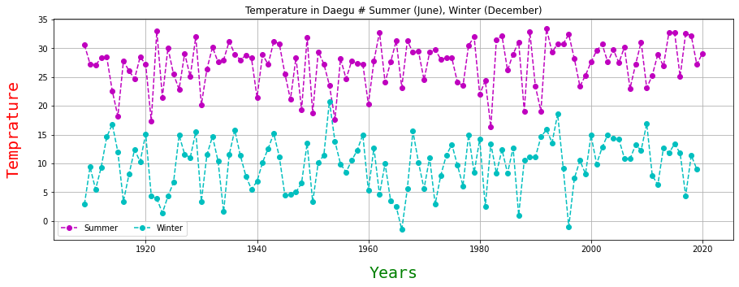

```python
import csv
import numpy as np
import matplotlib.pyplot as plt
f = open("./data/daegu.csv", encoding='cp949')
data = csv.reader(f)
summer = []
winter = []
s_date = []
w_date = []
next(data)

for row in data :
    if row[-1] != '' and row[0].split('-')[1] == '06' and row[0].split('-')[2] == '01' :
        s_date.append(float(row[0].split('-')[0]))
        summer.append(float(row[-1]))
    if row[-1] != '' and row[0].split('-')[1] == '12' and row[0].split('-')[2] == '01' :
        w_date.append(float(row[0].split('-')[0]))
        winter.append(float(row[-1]))

plt.figure(figsize=(15,5))
plt.title('Temperature in Daegu # Summer (June), Winter (December)')
plt.plot(s_date,summer,  'mo--', label="Summer")
plt.plot(w_date,winter, 'co--', label="Winter")
plt.grid(True)
plt.xlabel('Years', labelpad=15, fontdict={'family': 'monospace', 'color': 'g', 'weight': 'light', 'size': 20})
plt.ylabel('Temprature', labelpad=20, fontdict={'family': 'monospace', 'color': 'r', 'weight': 'light', 'size': 20})
plt.legend(loc='best', ncol=2)
plt.show()
```

## 4. AI 예측

예측을 제시하고, 이를 완성하시오.

## 5. 결론

AI 예측에서 예측한 결과를 분석하고. 이에 대한 자신의 팀의 결론 및 해석을 제시하시오.

꾸준히 나타나는 연교차 데이터를 통해 경제적으로 어려움을 겪고 있는 상인 뿐만이 아니라 소비자들의 지갑사정을 생각해서 상인들이 여름에 겨울 의복을 저렴한 가격에 팔고, 겨울에 여름 의복을 저렴하게 판다는 광고를 많이 표시해 소비자들이 상인들의 물건을 많이 사게 만들어 상인들의 경우에 물건을 잘 처리할 수 있고, 소비자는 저렴한 가격에 의복을 구할 수 있는 서로 간의 윈윈 관계를 만들어 낼 수 있게 된다.